# scRNAseq_shiny_app version 1.0.0

Katarzyna Sikora

3/5/2019

## What the app takes as input

- A single cell dataset pre-clustered with either RaceID3 or Monocle2 and saved in a serialized R object.
- The dataset can either be produced by the snakePipes scRNAseq workflow or by custom analysis as long as all the slots are populated.

## What the app can do

- Visualize the original clusters on a tsne map
- Allow the user to specify the desired number of clusters, re-cluster the dataset and visualize the updated clusters on a tsne map
- Extract cluster marker genes (up to 10 per cluster), summarize them in a table as well as visualize on a heatmap
- Allow the user to provide 1 or more gene IDs to visualize the expression for on a tsne map
- Calculate and list top10 most correlated genes to the genes provided by the user
- Plot pairwise expression for genes provided by the user

## How the app works

- The user provides either the information necessary to find the R object resulting from automated snakePipes analysis on the groups sequencing data volume, or provides full path to the object they processed with the required package, or uploads an RData file not exceeding 100Mb.
- A single cell object formatted and preprocessed with the respective package is loaded into memory.
- The processing is done either using RaceID3 functions or using a combination of Monocle2 (clustering, visualization) and Seurat3 (marker gene extraction and visualization) functions. In case of RaceID3 outlier detection is performed but ignored for visualization, such that only original clusters are considered.

## A note on processing speed

- The more data is loaded, the longer (some of) the functions will take - the app is not meant to work with very large datasets! Try to stay < 5000 cells.
- Data loading is rather slow, please allow some minutes, depending how large your dataset is. Depending on the package of choice, re-clustering or extracting cluster markers might also be a slow calculation.

## Dataset selection

Select the genome your data was quantified against from the pulldown list.  
Select R package that you’d like to conduct the analysis with from the “Select input file format” pulldown list.

To retrieve a dataset that has been processed with snakePipes scRNAseq workflow (at least version 1.1.0), fill in the fields “Group”,“Project Owner”,“Project ID”. To retrieve a dataset from a custom path, provide full path to *RData object under “Data path”, leaving the other fields empty. To upload a dataset from a custom path, use the ‘Browse’ button in the “Choose file to upload” field.

Hint: the dataset must be fully processed and contain the initial clustering information!  
Hint2: for RaceID, the dataset must be preprocessed with version 3 of the package. For Monocle, with version 2.

This vignette showcases the use of a dataset from a custom path.

# Example1: RaceID

A published dataset stored under “/data/processing/scRNAseq_shiny_app_example_data/GSE81076_raceid.workspaceR/sc.minT1000.RData” will be analyzed. See Grün D, Muraro MJ, Boisset JC, Wiebrands K et al. De Novo Prediction of Stem Cell Identity using Single-Cell Transcriptome Data. Cell Stem Cell 2016 Aug 4;19(2):266-277 for the original publication.

Select human hg38 genome and RaceID3 as analysis package. Provide the unquoted path to data and click on ‘Select dataset’ (Figure 1).

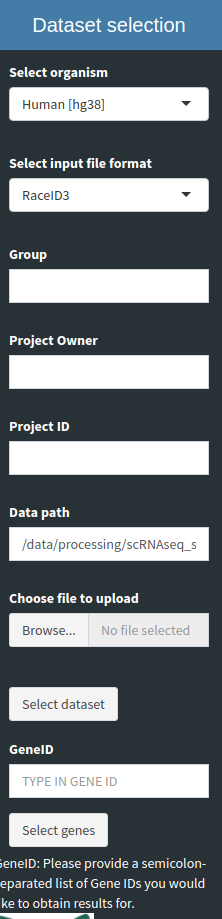

Figure 1: Dataset selection

After some lag, the head of the normalized data appears in the “Input data” tab (Figure 2). You can also check the dimensions of your matrix and the summary of the TPC (transcript per cell) distribution in the corresponding boxes.

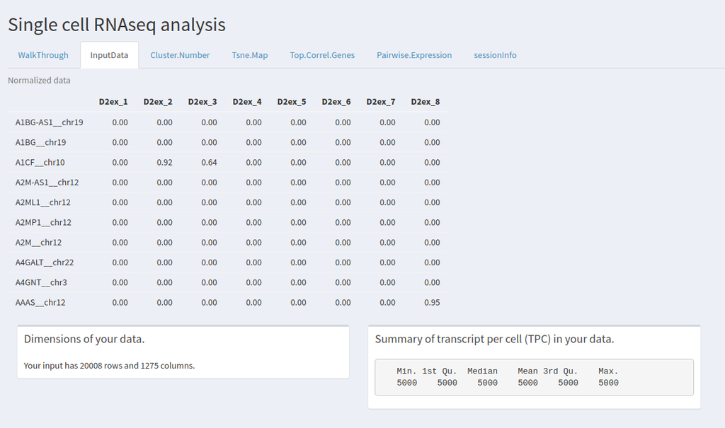

Figure 2: Head of normalized counts

In the “Cluster.Number” tab, a plot of the within-cluster dispersion as a function of cluster number will appear in the “Metrics for cluster number selection” box (Figure 3). Use this information to guide your cluster number choice as described in the package vignette.  
The dataset was originally clustered into 6 clusters. To visualize this on a tsne map, click on ‘Plot clusters on tsne’ without changing the cluster number ruler (Figure 3).

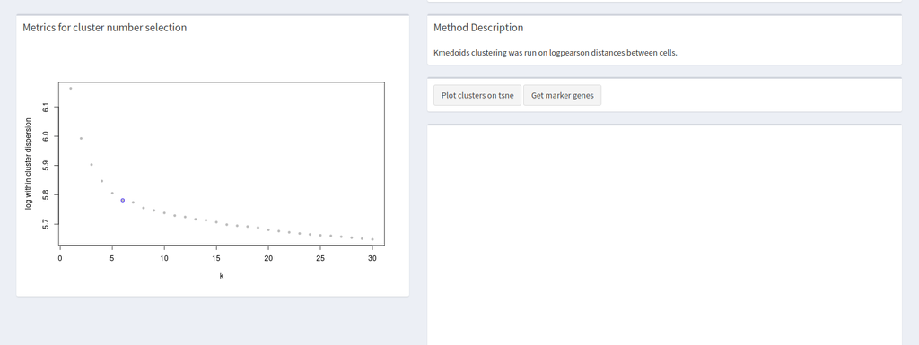

Figure 3: Cluster number selection A)Metric for cluster number selection

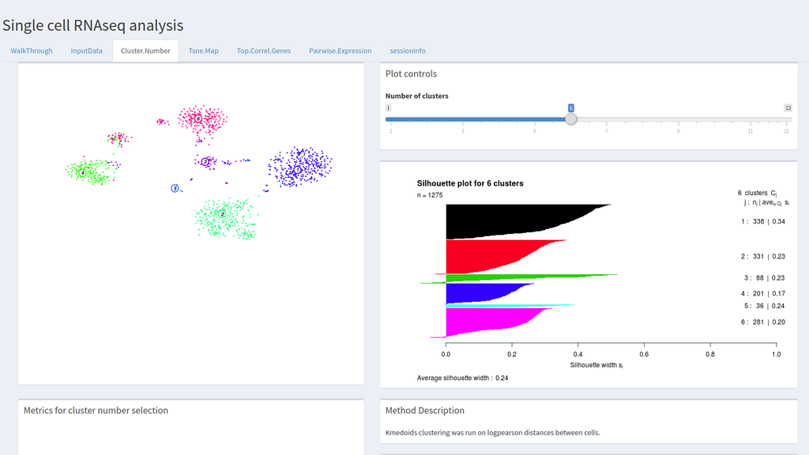

Figure 3: Cluster number selection B)Cluster membership plot

Along with the cluster membership tsne plot, a silhouette plot illustrating cluster assignment quality is displayed.

You decide to change the number of clusters to e.g. 4. Update the value on the ruler and click again on ‘Plot clusters on tsne’. This initiates re-clustering, and after a waiting time, the updated tsne and silhouette plots replace the old plots (Figure 4).

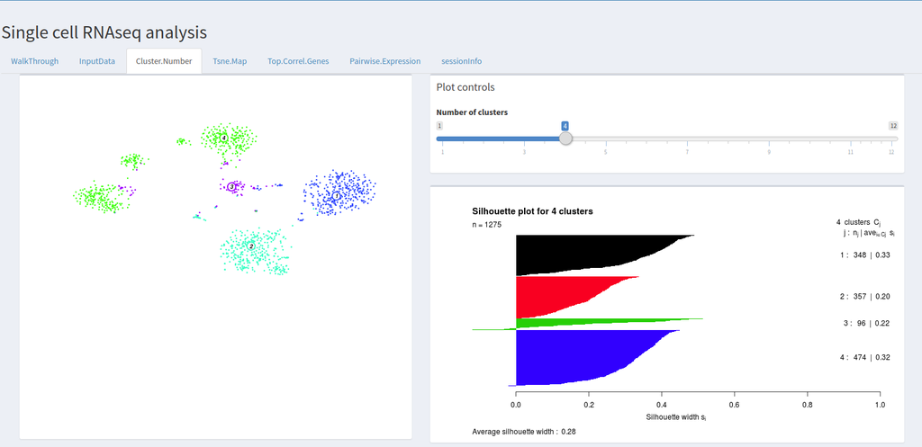

Figure 4: Update cluster number choice

To obtain markers (by default: 2) for each cluster, click on ‘Get marker genes’. After a rather long while, a table with top markers as well as a heatmap corresponding to it appears (Figure 5).

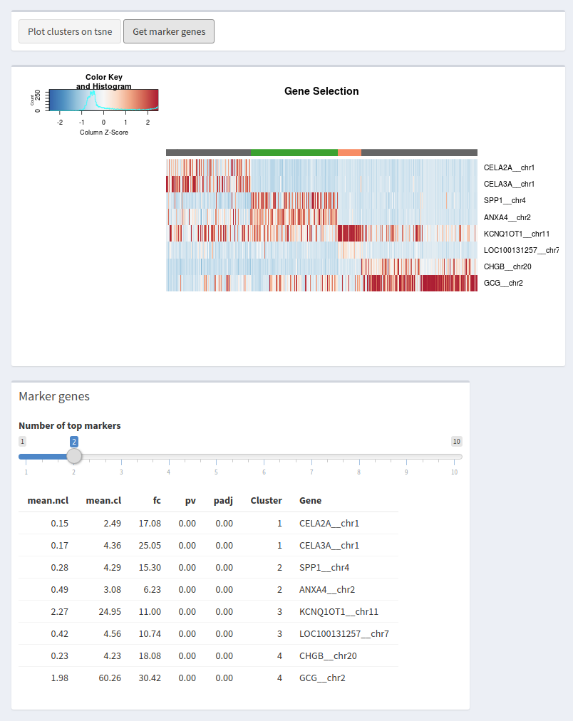

Figure 5: Top marker genes

To download the table, use the ‘Download table’ button. To increase the number of markers displayed in the table and on the heatmap, move the ruler above the table. The two outputs will be updated (Figure 6).

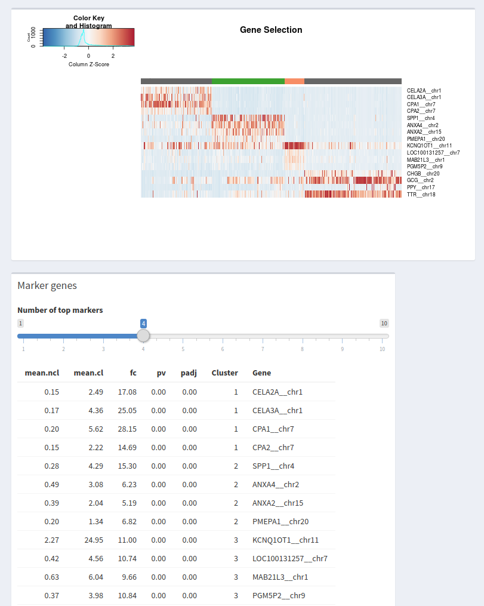

Figure 6: Top marker genes

To select a gene for visualisation, copy one of the top markers into the “GeneID” field on the side bar and click on ‘Select genes’ (Figure 7).

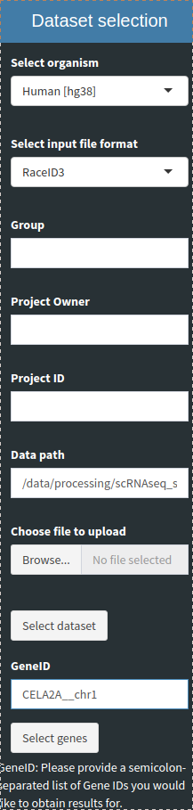

Figure 7: Select genes for visualisation

Check that the gene is expressed in the ‘Genes used’ field in the ‘Tsne.Map’ tab (Figure 8).

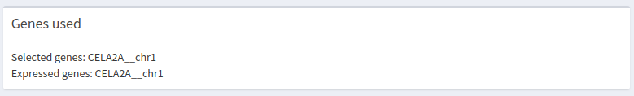

Figure 8: Genes used

Click on ‘Plot tsne map’ to visualise gene expression for that gene (Figure 9). You can modify plot title as well as scale of the counts.

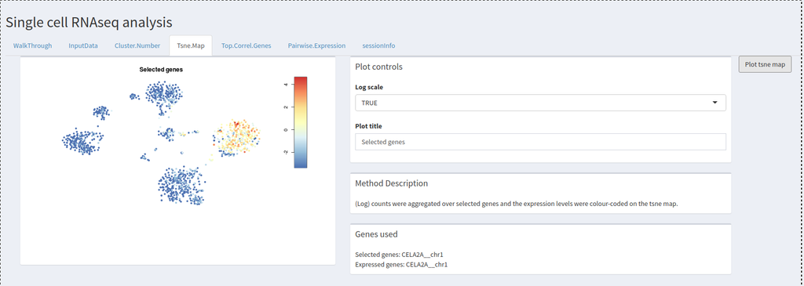

Figure 9: Tsne map with marker genes

Automatically, top 10 correlated genes will be listed in the ‘Top.Correl.Genes’ tab (Figure 10).

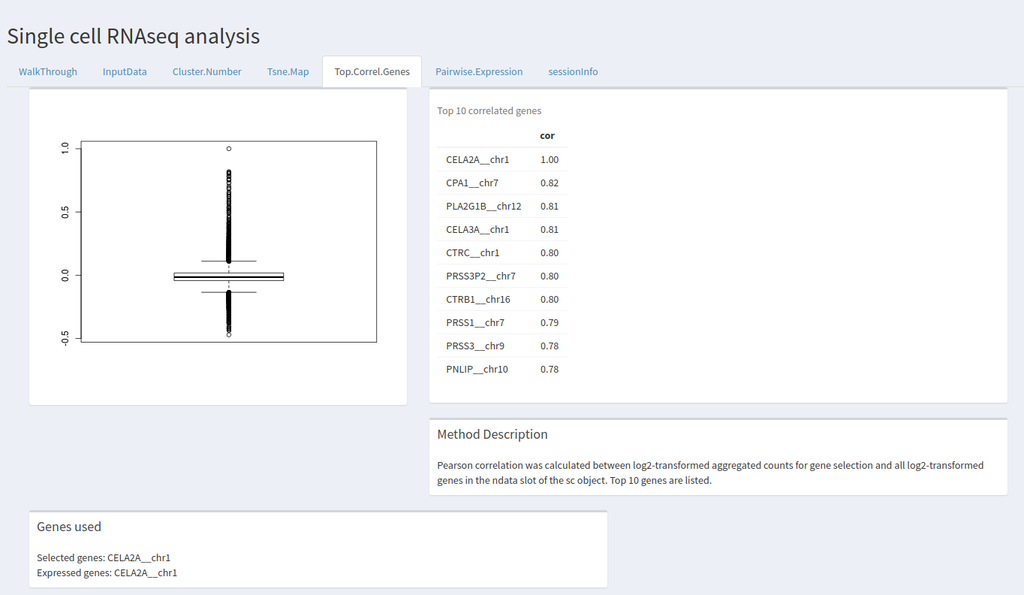

Figure 10: Top correlated genes

You may plot pairwise correlation for selected genes in the ‘Pairwise.Expression’ tab. Fill in the genes to use for the X and Y axis and click on ‘Plot expression’ (Figure 11).

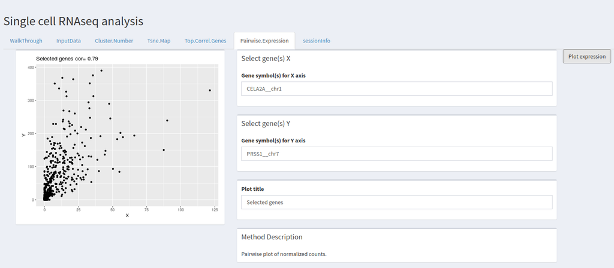

Figure 11: Pairwise expression

# Example2: Monocle

A published dataset stored under “/data/processing/scRNAseq_shiny_app_example_data/GSE81076_monocle.workspaceR/minT5000.mono.set.RData” will be analyzed. See Grün D, Muraro MJ, Boisset JC, Wiebrands K et al. De Novo Prediction of Stem Cell Identity using Single-Cell Transcriptome Data. Cell Stem Cell 2016 Aug 4;19(2):266-277 for the original publication.

Select human hg38 genome and Monocle as analysis package. Provide the unquoted path to data and click on ‘Select dataset’ (Figure 14).

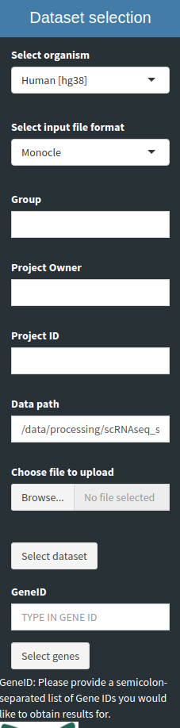

Figure 14: Dataset selection

After some lag, the head of the normalized data appears in the “Input data” tab (Figure 15). You can also check the dimensions of your matrix and the summary of the TPC (transcript per cell) distribution in the corresponding boxes.

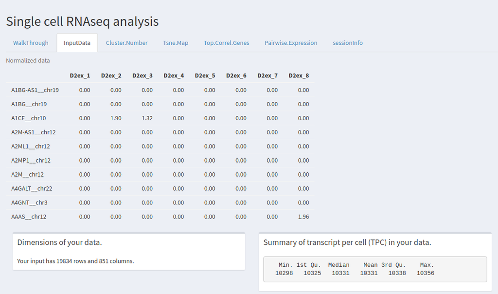

Figure 15: Head of normalized counts

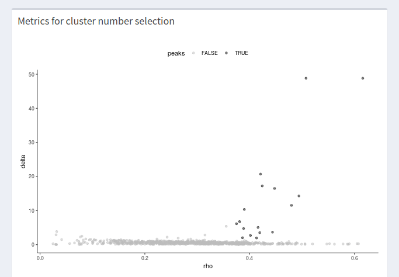

Figure 16: Plot cluster membership A)Metric for cluster number selection

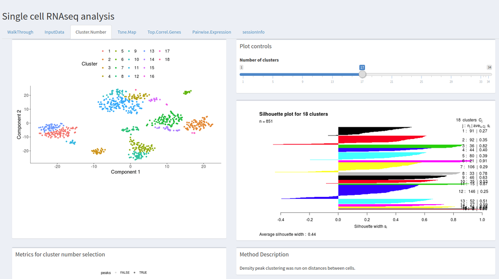

Figure 16: Plot cluster membership B)Cluster membership plot

Along with the cluster membership tsne plot, a silhouette plot illustrating cluster assignment quality is displayed.

You decide to change the number of clusters to e.g. 4. Update the value on the rule and click again on ‘Plot clusters on tsne’. This initiates re-clustering, and after a waiting time, the updated tsne and silhouette plots replace the old plots (Figure 17).

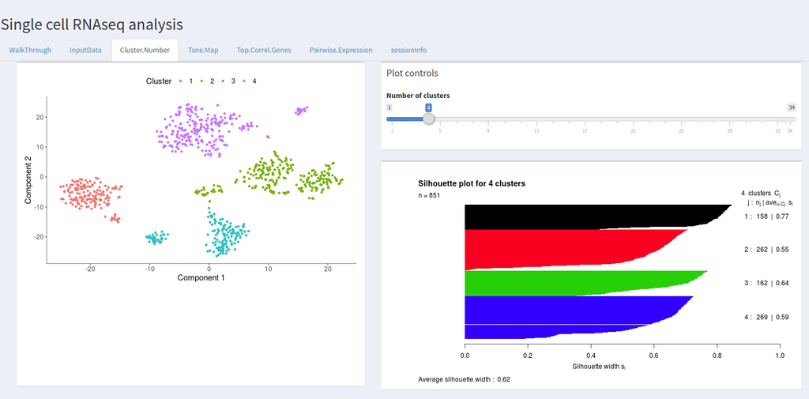

Figure 17: Updated number of clusters

To obtain markers (by default: 2) for each cluster, click on ‘Get marker genes’. After a rather long while, a table with top markers as well as a heatmap corresponding to it appears (Figure 18). This calculation is done using the Bioconductor scRNAseq analysis package ‘Seurat’.

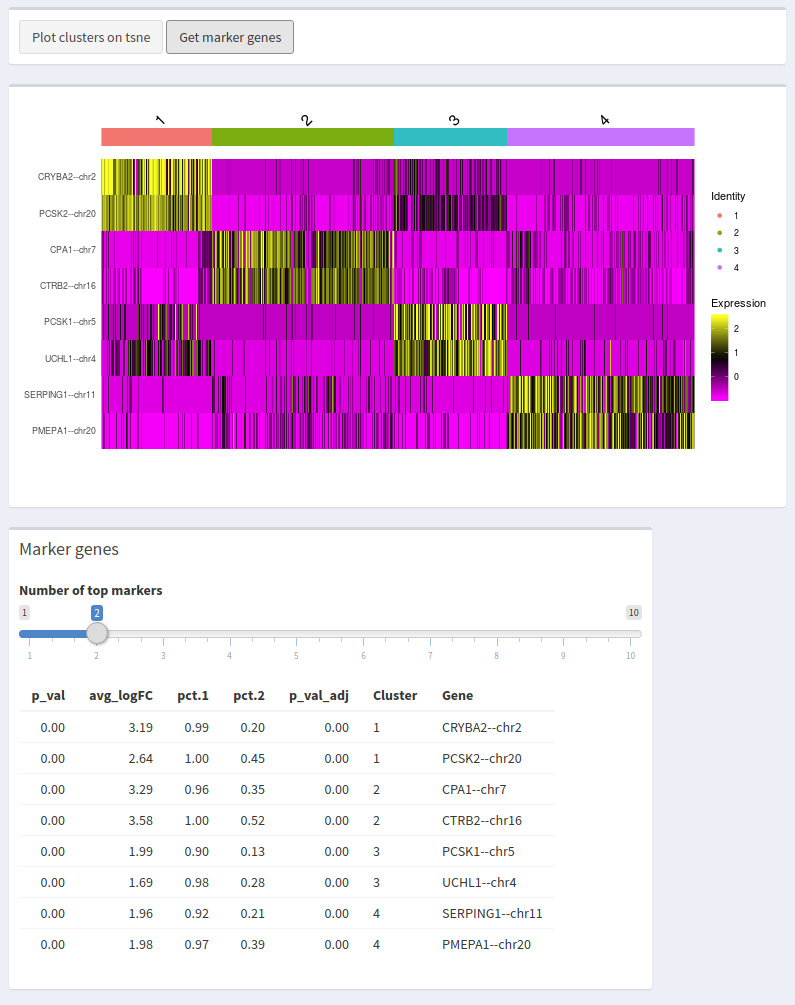

Figure 18: Top marker genes

To download the table, use the ‘Download table’ button. To increase the number of markers displayed in the table and on the heatmap, move the ruler above the table. The two outputs will be updated (Figure 19).

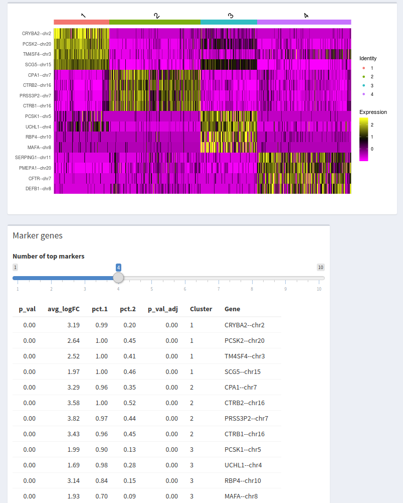

Figure 19: Top marker genes

To select a gene for visualisation, copy one of the top markers into the “GeneID” field on the side bar and click on ‘Select genes’ (Figure 20).

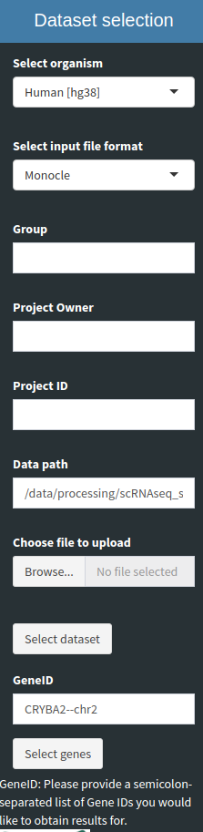

Figure 20: Select genes for visualisation

Check that the gene is expressed in the ‘Genes used’ field in the ‘Tsne.Map’ tab. Click on ‘Plot tsne map’ to visualise gene expression for that gene (Figure 21). You can modify plot title as well as scale of the counts.

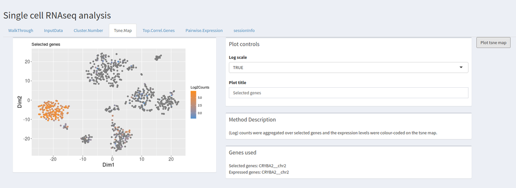

Figure 21: Genes used

The remaining functions work as described in Example 1 with RaceID3 input.

# General: Documenting your analysis

To keep trace of the parameters you used to generate your plots, it is recommended that you code them either into the plot titles (customizable by the user) or into the file names under which you save your plots.

To keep trace of the R and R packages versions, you might want to inspect the ‘sessionInfo’ tab. This contains the output of the sessionInfo() R command (Figure 27). At the bottom of the page, two buttons are available (Figure 28). Click on ‘Download session info’ or ‘Download your data’ to save the respective file on your computer.

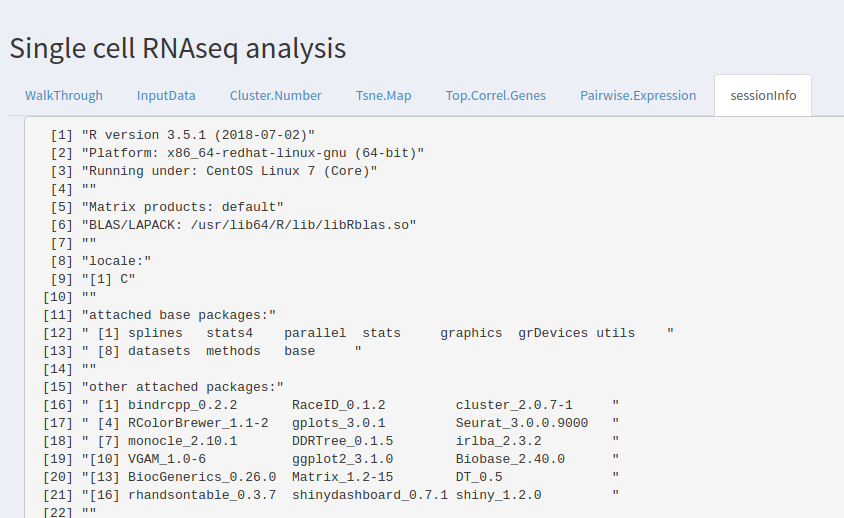

Figure 27: Session Info tab

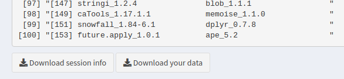

Figure 28: Download documentation

Lastly, the code behind the app can be retrieved under “https://github.com/maxplanck-ie/scRNAseq_shiny_app” for the given version of the app. The latter you can read at the bottom of the side bar (Figure 29).

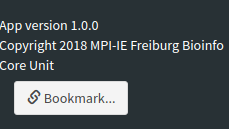